# Lab 1 - Anomaly Detection

Yamit Ibarra

Submission date: 4. April 2021

First, packages are loaded.

```r
library(ggplot2)
library(readr)
```

## 1. Task: CHP Unit

### Data

CHP.csv contains the data of a *combined heat and power plant* in Germany. The data spans the month of January 2021 and was recorded in intervals of one minute.

```r
# read the data
dat <- read.csv("C:/Users/yamid/OneDrive/Documentos/MASTER HS OFFENBURG/SECOND SEMESTER/Data Engineering 2/Labs/01 Lab/CHP.csv")
# parse the date
dat$DateTime <- as.POSIXlt(dat$DateTime)
summary(dat)
```

```
##     DateTime                     BHhkwOnOff     AussenTemperatur
##  Min.   :2021-01-01 00:00:00   Min.   :0.0000   Min.   :-3.812
##  1st Qu.:2021-01-08 17:59:45   1st Qu.:0.0000   1st Qu.: 2.125
##  Median :2021-01-16 11:59:30   Median :1.0000   Median : 3.000
##  Mean   :2021-01-16 11:59:29   Mean   :0.6754   Mean   : 3.797
##  3rd Qu.:2021-01-24 05:59:15   3rd Qu.:1.0000   3rd Qu.: 4.875
##  Max.   :2021-01-31 23:59:00   Max.   :1.0000   Max.   :13.437
##  SpeicherUnten   SpeicherMitte      SpeicherOben
##  Min.   :35.81   Min.   :-124.69   Min.   :47.62
##  1st Qu.:42.75   1st Qu.:  51.94   1st Qu.:78.81
##  Median :46.69   Median :  67.94   Median :79.69
##  Mean   :49.43   Mean   :  65.68   Mean   :78.92
##  3rd Qu.:55.12   3rd Qu.:  78.94   3rd Qu.:80.94
##  Max.   :73.31   Max.   : 127.94   Max.   :90.06
```

The dataset contains the following columns:

- DateTime: Date and time of the record
- BHhkwOnOff: 1 if the CHP unit was powered on, 0 otherwise
- AussenTemperatur: Outdoor temperature in °C
- SpeicherUnten, SpeicherMitte, SpeicherOben: The storage temperatures in °C at the bottom, mid, and the top.

```r
str(dat)
```

```
## 'data.frame':    44640 obs. of  6 variables:
##  $ DateTime        : POSIXlt, format: "2021-01-01 00:00:00" "2021-01-01 00:01:00" ...
##  $ BHhkwOnOff      : int  0 0 0 0 0 0 0 0 0 0 ...
##  $ AussenTemperatur: num  4.62 4.44 4.5 4.5 4.56 ...
##  $ SpeicherUnten   : num  46 45.9 45.8 45.8 45.8 ...
##  $ SpeicherMitte   : num  50.9 50.8 50.8 50.8 50.8 ...
##  $ SpeicherOben    : num  71.4 71.3 71.2 71.1 70.9 ...
```

### Visualization

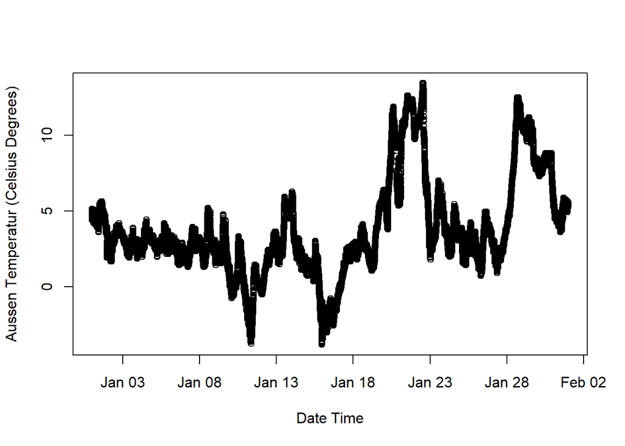

```r
plot(dat$DateTime, dat$AussenTemperatur, xlab = "Date Time",
     ylab = "Aussen Temperatur (Celsius Degrees)")
```

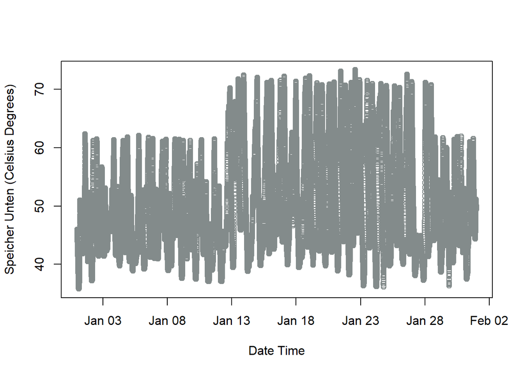

```r
plot(dat$DateTime, dat$SpeicherUnten, xlab = "Date Time",
     ylab = "Speicher Unten (Celsius Degrees)", type = "p", col="azure4")
```

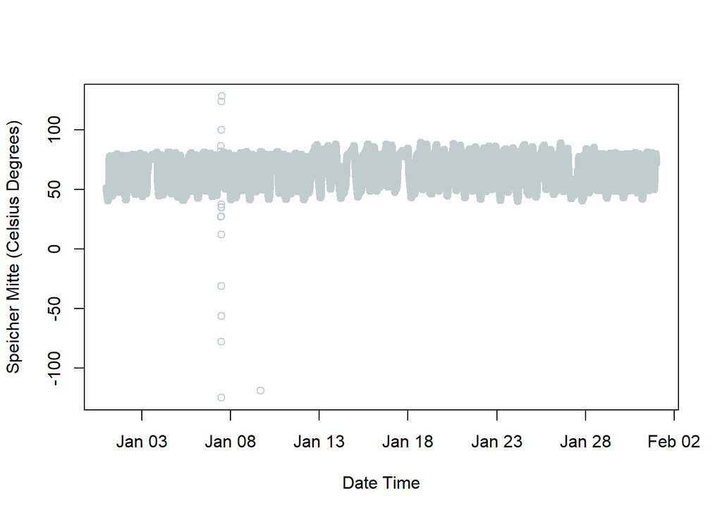

```r
plot(dat$DateTime, dat$SpeicherMitte, xlab = "Date Time",
     ylab = "Speicher Mitte (Celsius Degrees)" , type = "p", col="azure3")
```

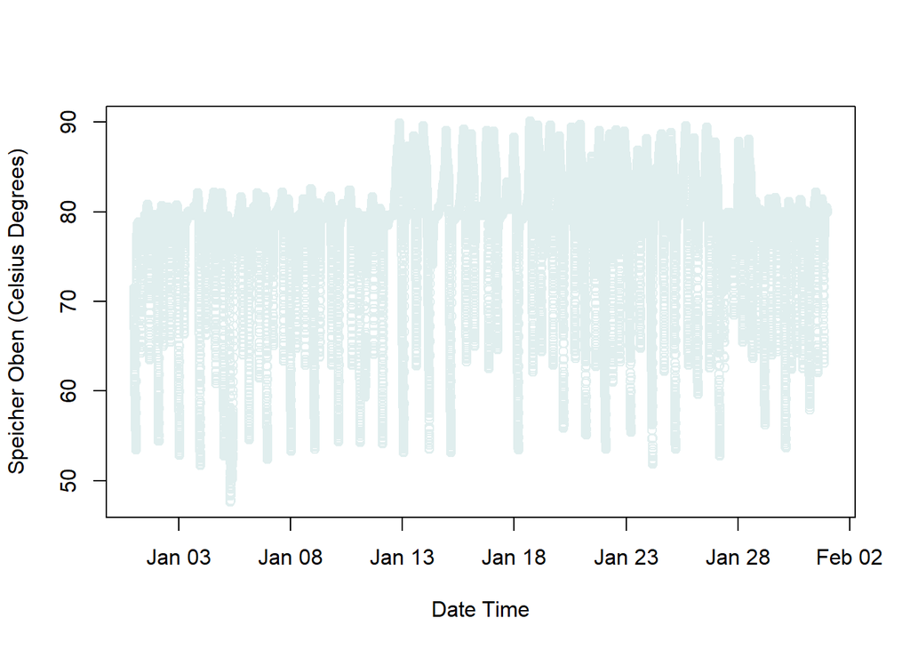

```r
plot(dat$DateTime, dat$SpeicherOben, xlab = "Date Time",
     ylab = "Speicher Oben (Celsius Degrees)", type = "p", col="azure2")
```

### Problem description

Around the 11th of January a software update was performed. That update lead to a malfunction of the control of the CHP unit in the following days. Between the beginning of January and the 11th the CHP unit was working normally. That data will serve as our training data for a semi-supervised anomaly detection and a unsupervised anomaly detection. The anomaly detection should be based on the storage temperatures (last three features).

```r
# store the features that will be used for the anomaly detection
features <- c("SpeicherUnten", "SpeicherMitte", "SpeicherOben")
# select the data from 1.1 - 11.1
trainIndex <- 1:15000
train <- dat[trainIndex,]
```

### EDA

Perform a brief EDA on the training data

```r
summary(train)
```

```
##     DateTime                     BHhkwOnOff     AussenTemperatur
##  Min.   :2021-01-01 00:00:00   Min.   :0.0000   Min.   :-3.750
##  1st Qu.:2021-01-03 14:29:45   1st Qu.:0.0000   1st Qu.: 2.250
##  Median :2021-01-06 04:59:30   Median :1.0000   Median : 2.812
##  Mean   :2021-01-06 04:59:30   Mean   :0.7053   Mean   : 2.615
##  3rd Qu.:2021-01-08 19:29:15   3rd Qu.:1.0000   3rd Qu.: 3.375
##  Max.   :2021-01-11 09:59:00   Max.   :1.0000   Max.   : 5.625
##  SpeicherUnten   SpeicherMitte      SpeicherOben
##  Min.   :35.81   Min.   :-124.69   Min.   :47.62
##  1st Qu.:42.12   1st Qu.:  50.06   1st Qu.:78.06
##  Median :45.25   Median :  64.38   Median :79.19
##  Mean   :46.56   Mean   :  63.66   Mean   :77.16
##  3rd Qu.:50.38   3rd Qu.:  77.88   3rd Qu.:79.88
##  Max.   :62.31   Max.   : 127.94   Max.   :82.56
```

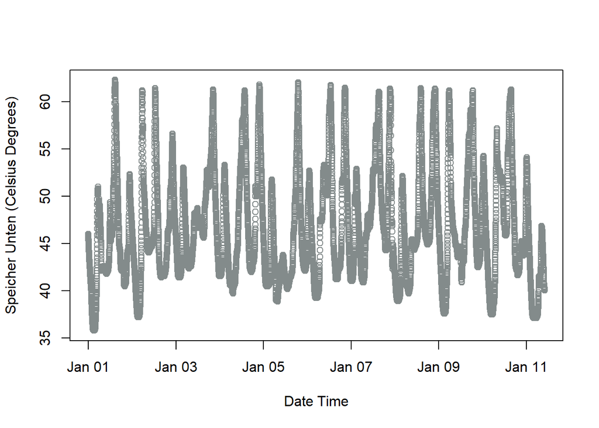

```r
plot(train$DateTime, train$SpeicherUnten, xlab = "Date Time",
     ylab = "Speicher Unten (Celsius Degrees)", col="azure4")
```

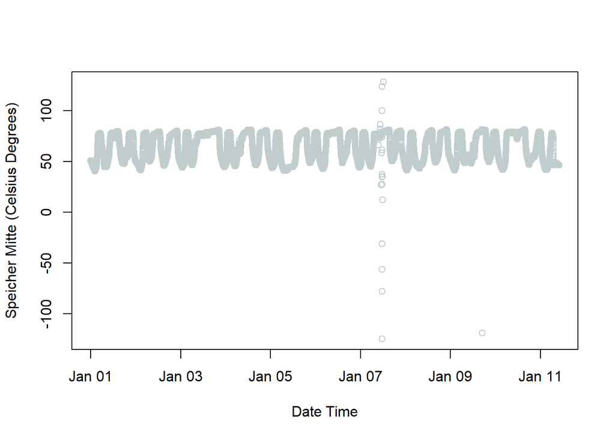

```r
plot(train$DateTime, train$SpeicherMitte , xlab = "Date Time",
     ylab = "Speicher Mitte (Celsius Degrees)", type = "p", col="azure3")
```

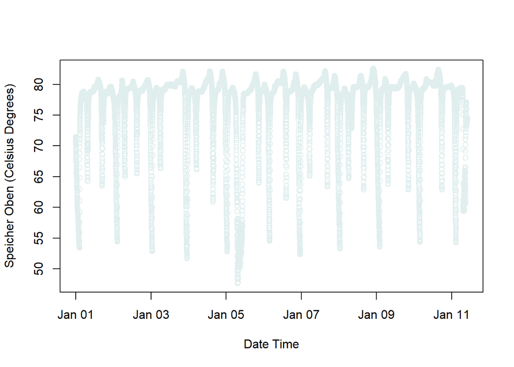

```r
plot(train$DateTime, train$SpeicherOben, xlab = "Date Time",
     ylab = "Speicher Oben (Celsius Degrees)", type = "p", col="azure2")
```

### EDA

Comparison of data before and after the CHP software update.

Unten Temperature

Below: Data before the 11th of January on yellow color. Data after the 11th of January on grey color.

Vertical orange line indicates temperature values higher than the normal ones after the software update. Values of Unten temperature higher than 64 Celsius could indicate anomaly after the software update.

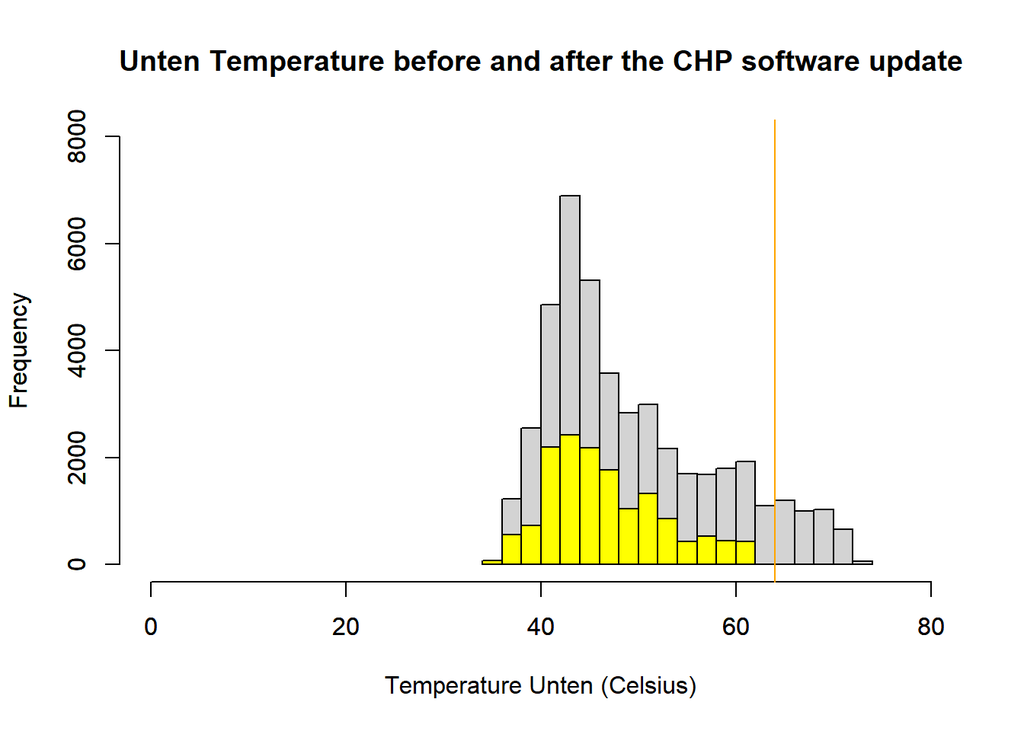

```r
  hist(dat$SpeicherUnten, breaks= 20, xlab= "Temperature Unten (Celsius)",
       xlim = range(0, 80), ylim = range(0,8000),
       main = "Unten Temperature before and after the CHP software update")
  par(new=TRUE)
  hist(train$SpeicherUnten, breaks = 10, col = c("#FFFF00"), main = "",
       xlab = "", xlim= range(0,80),ylim = range(0,8000))
  abline(v=64, col="orange")
```

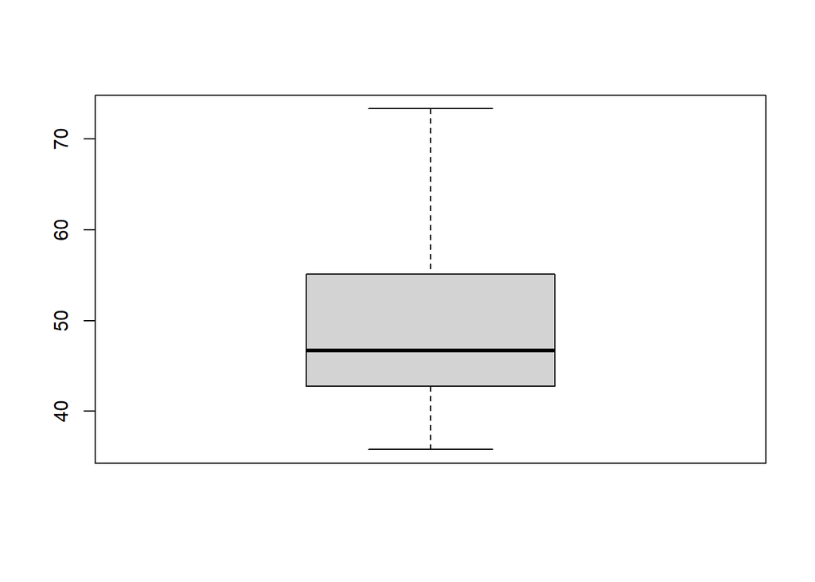

```r
   boxplot(dat$SpeicherUnten)
```

Mitte Temperature

Below: Data before the 11th of January on orange color. Data after the 11th of January on grey color.

Mitte temperature values higher than 80 Celsius are more frecuent after the software update.

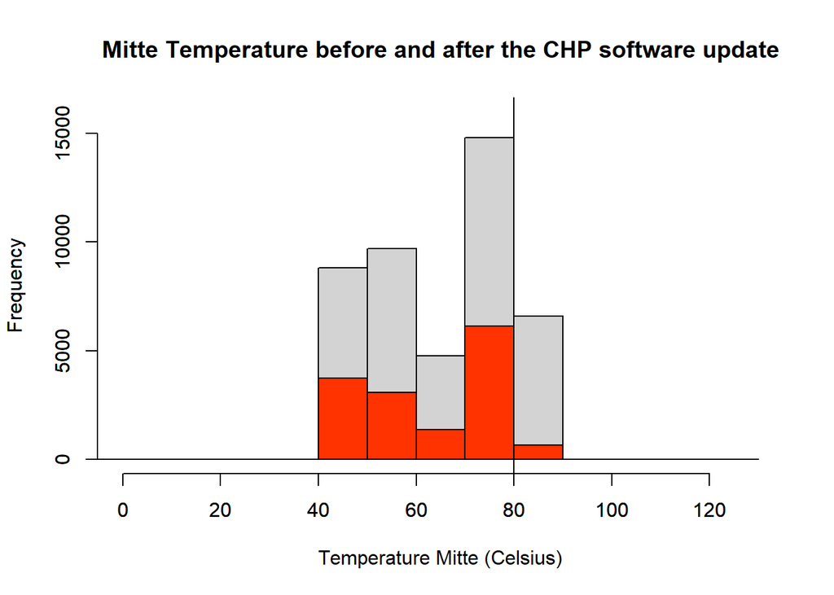

```r
  hist(dat$SpeicherMitte, breaks= 30, xlab= "Temperature Mitte (Celsius)",
       xlim = range(0, 130), ylim = range(0,16000),
       main = "Mitte Temperature before and after the CHP software update")
  par(new=TRUE)
  hist(train$SpeicherMitte, breaks = 30, col = c("#FF3300"), main = "",
       xlab = "", xlim= range(0, 130),ylim = range(0,16000))
  abline(v=80, col="black")
```

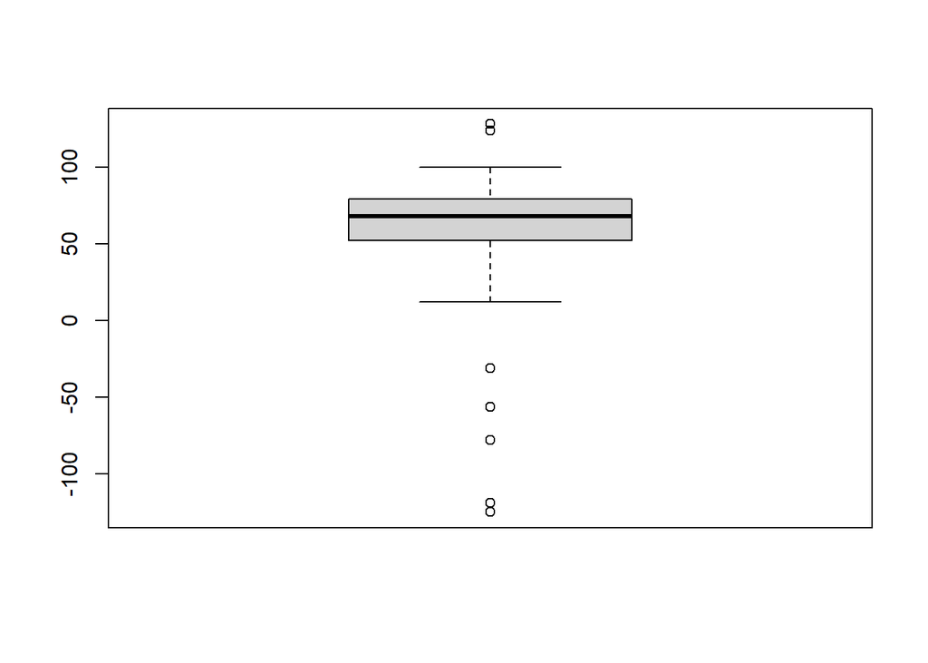

```r
  boxplot(dat$SpeicherMitte)
```

Oben Temperature

Below: Data before the 11th of January on red color. Data after the 11th of January on grey color.

Oben temperature values higher than 84 Celsius could indicate anomaly after the software update.

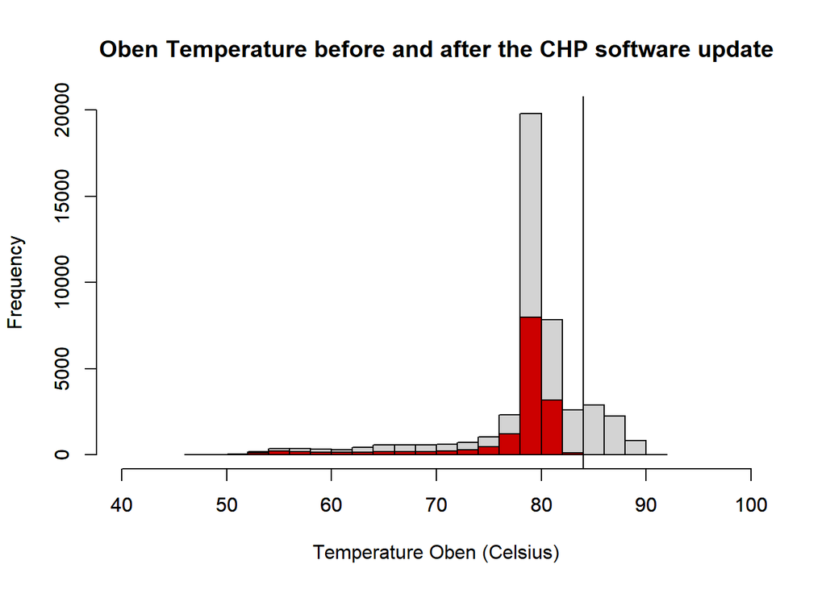

```r
  hist(dat$SpeicherOben, breaks= 20, xlab= "Temperature Oben (Celsius)",
       xlim = range(40, 100), ylim = range(0,20000),
       main = "Oben Temperature before and after the CHP software update")
  par(new=TRUE)
  hist(train$SpeicherOben, breaks = 20, col = c("#CC0000"), main = "",
       xlab = "", xlim= range(40, 100),ylim = range(0,20000))
  abline(v=84, col="black")
```

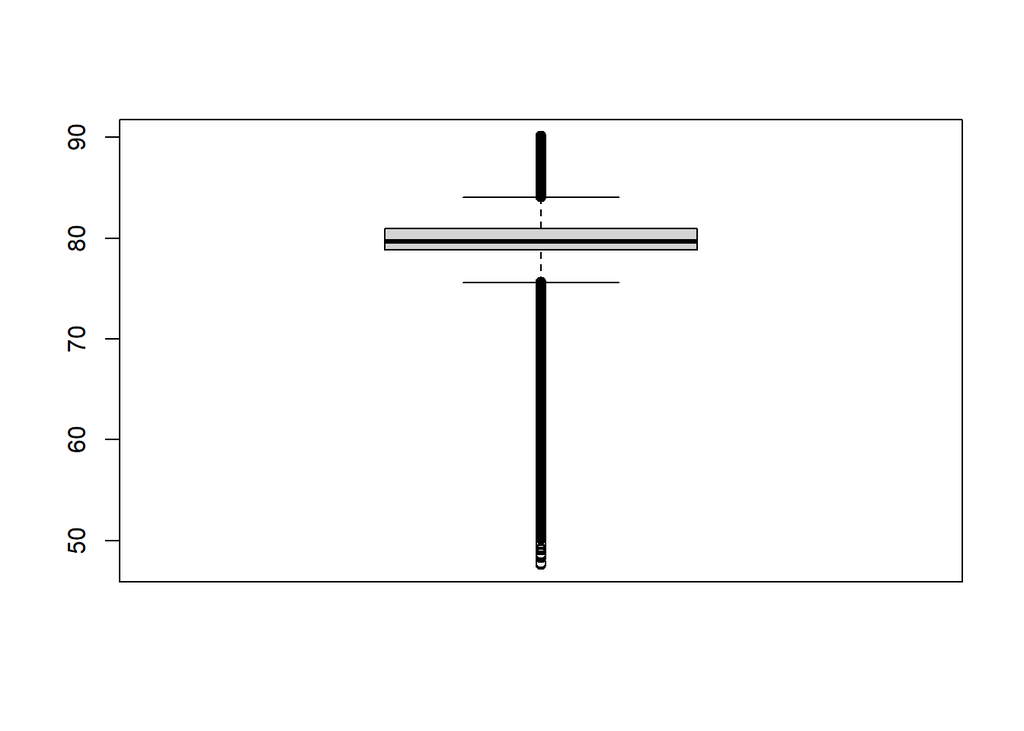

```r
   boxplot(dat$SpeicherOben)
```

### 1.1 One-class SVM Anomaly Detection

Train a *one-class* SVM model using the *e1071* package. The SVM predicts if a data point belongs to the normal class (output is *true*) or not (output is *false*).

Tune the *nu* parameter in order to get a reasonable classifications on the training set.

```r
library(e1071) # contains svm model
# train a svm

svm.model <- svm(train[,features], type = "one-classification", nu = 0.01)

# determine which points are considered normal on the training set
pred_train <- predict(svm.model, train[,features])
```

Count the number of normal and anomalous instances.

```r
table(pred_train)
```

```
## pred_train
## FALSE  TRUE
##   149 14851
```

Plot the training data, color the points as grey (normal) or red (anomaly)

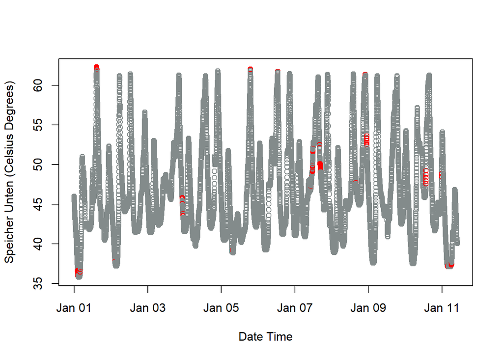

```r
plot(dat$DateTime[trainIndex], dat$SpeicherUnten[trainIndex],
     xlab = "Date Time", ylab = "Speicher Unten (Celsius Degrees)",
     col = ifelse(pred_train, "azure4", "red"))
```

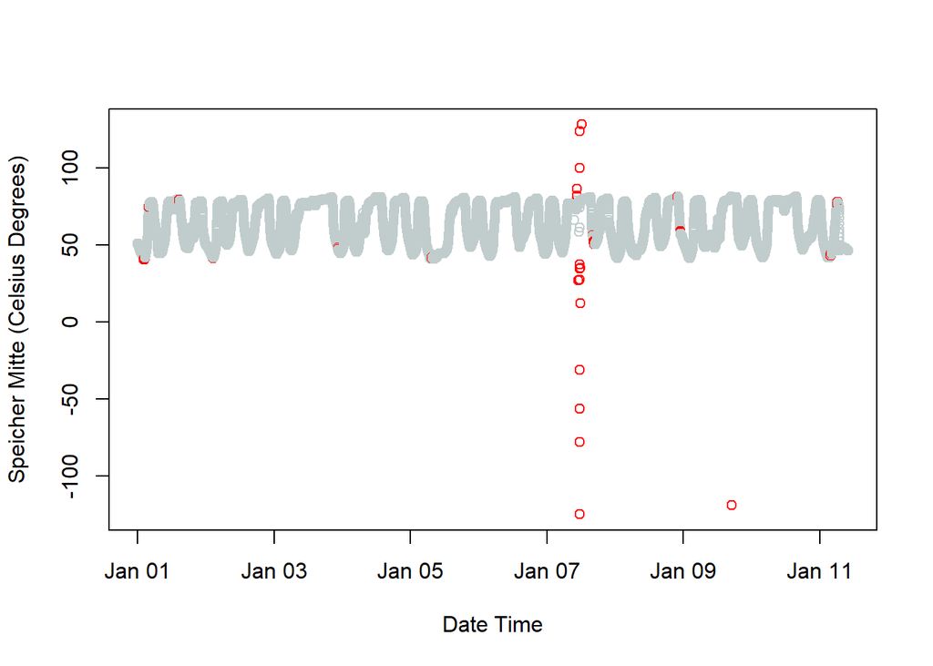

```r
plot(dat$DateTime[trainIndex], dat$SpeicherMitte[trainIndex],
     xlab = "Date Time", ylab = "Speicher Mitte (Celsius Degrees)",
     col = ifelse(pred_train, "azure3", "red"))
```

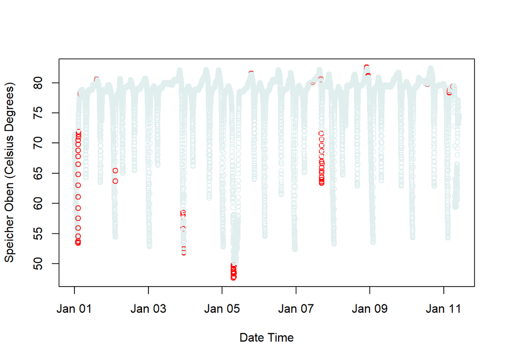

```r
plot(dat$DateTime[trainIndex], dat$SpeicherOben[trainIndex],
      xlab = "Date Time", ylab = "Speicher Oben (Celsius Degrees)",
     col = ifelse(pred_train, "azure2", "red"))
```

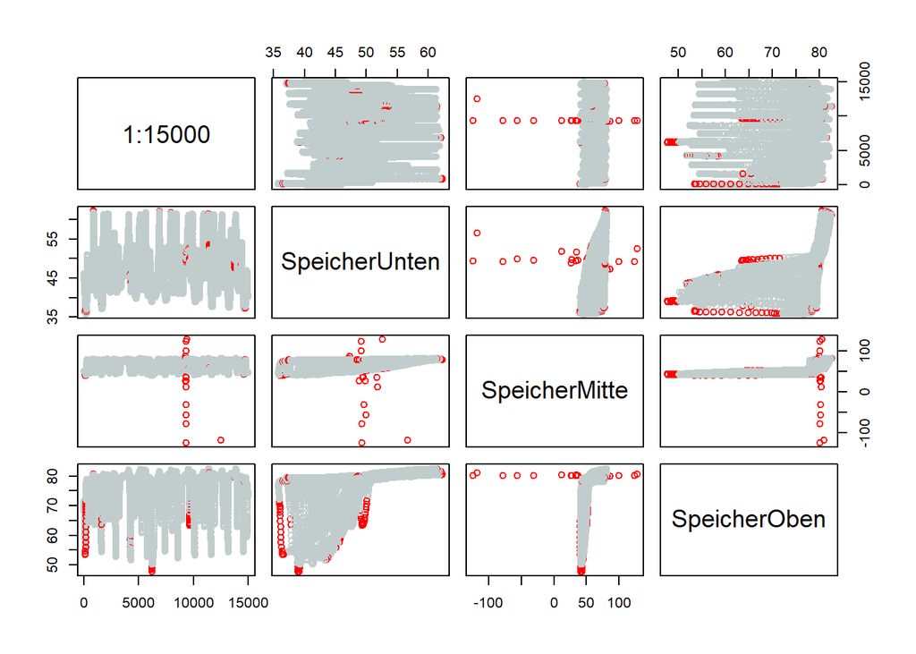

```r
pairs(cbind(1:15000, train[,4:6]),
      col = ifelse(pred_train, "azure3", "red"))
```

How does the parameter *nu* influence the one-class classification boundary?

**Your answer: The higher the nu, the higher the anomaly values the svm model** **classifies.** **This value was tested at 0.5, 0.1, 0.01.** **Finally, 0.01 was found as the best value.** **nu is a percentage taken by the model as anomaly values.** **For the training dataset, the number of anomaly instances is 149**

Use the *one-class* SVM to find anomalies in the entire data set

```r
# determine which points are considered normal on the whole data set
pred_total <- predict(svm.model, dat[,features])


# Count the number of normal and anomalous instances
table(pred_total)
```

```
## pred_total
## FALSE  TRUE
##  9268 35372
```

**For the whole dataset, the number of anomaly instances is 9268**

Plot the whole data set, color the points as grey (normal) or red (anomaly)

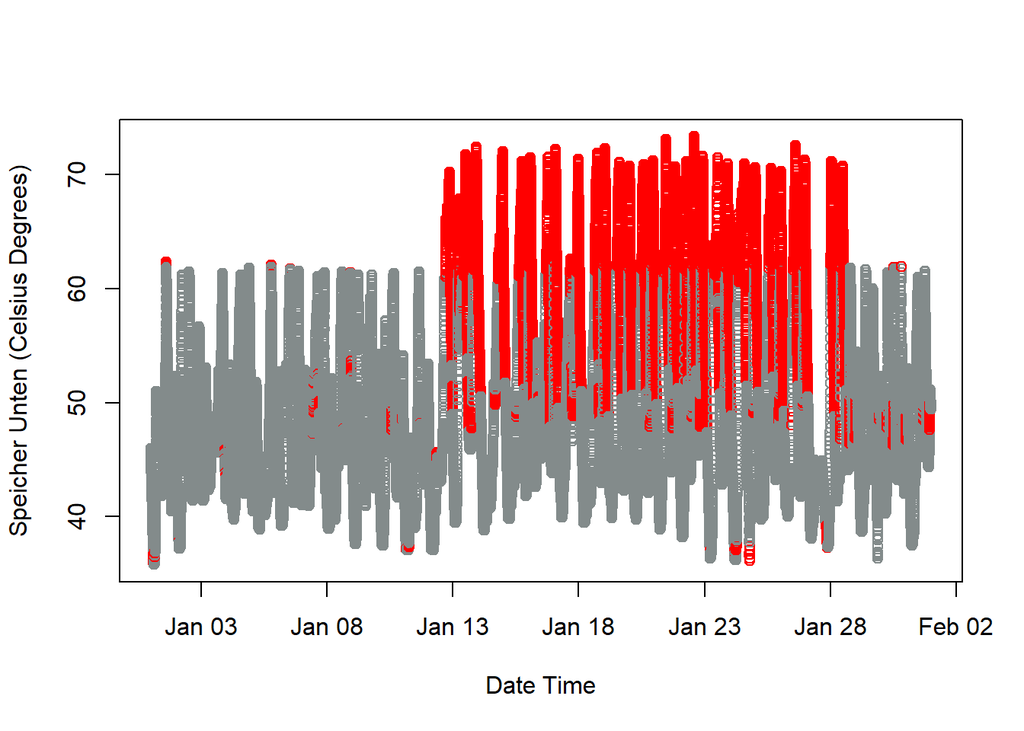

```r
plot(dat$DateTime, dat$SpeicherUnten,
      xlab = "Date Time", ylab = "Speicher Unten (Celsius Degrees)",
     col = ifelse(pred_total, "azure4", "red"))
```

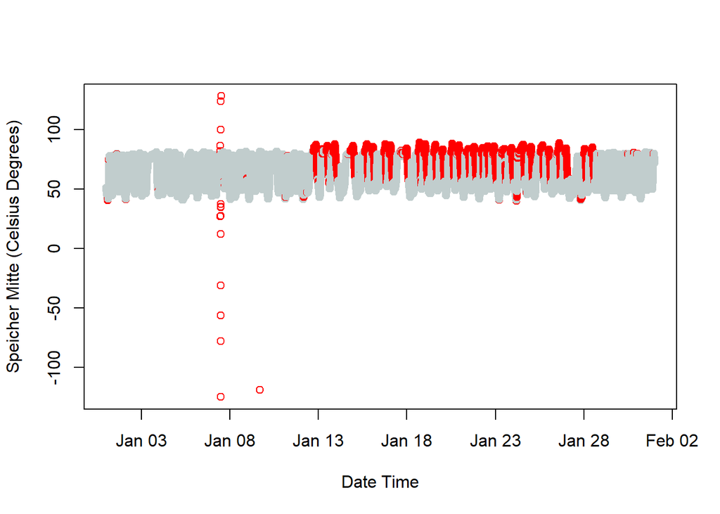

```r
plot(dat$DateTime, dat$SpeicherMitte,
      xlab = "Date Time", ylab = "Speicher Mitte (Celsius Degrees)",
     col = ifelse(pred_total, "azure3", "red"))
```

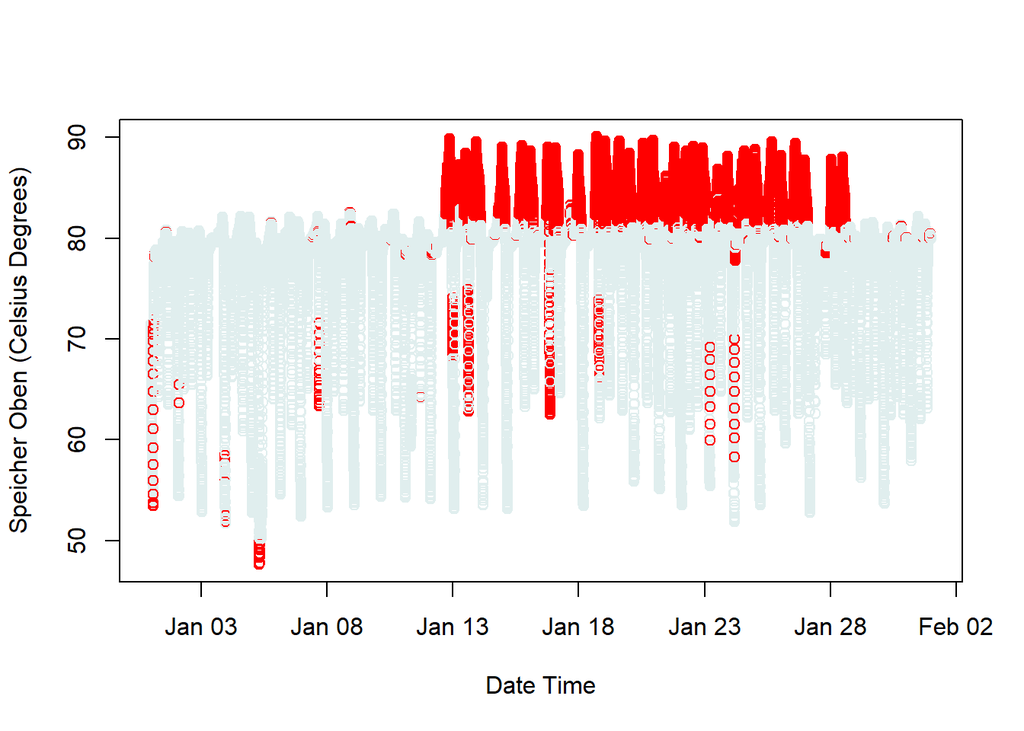

```r
plot(dat$DateTime, dat$SpeicherOben,
      xlab = "Date Time", ylab = "Speicher Oben (Celsius Degrees)",
     col = ifelse(pred_total, "azure2", "red"))
```

**The number of anomalies found in the whole dataset** **9268 for a nu value of 0.01**

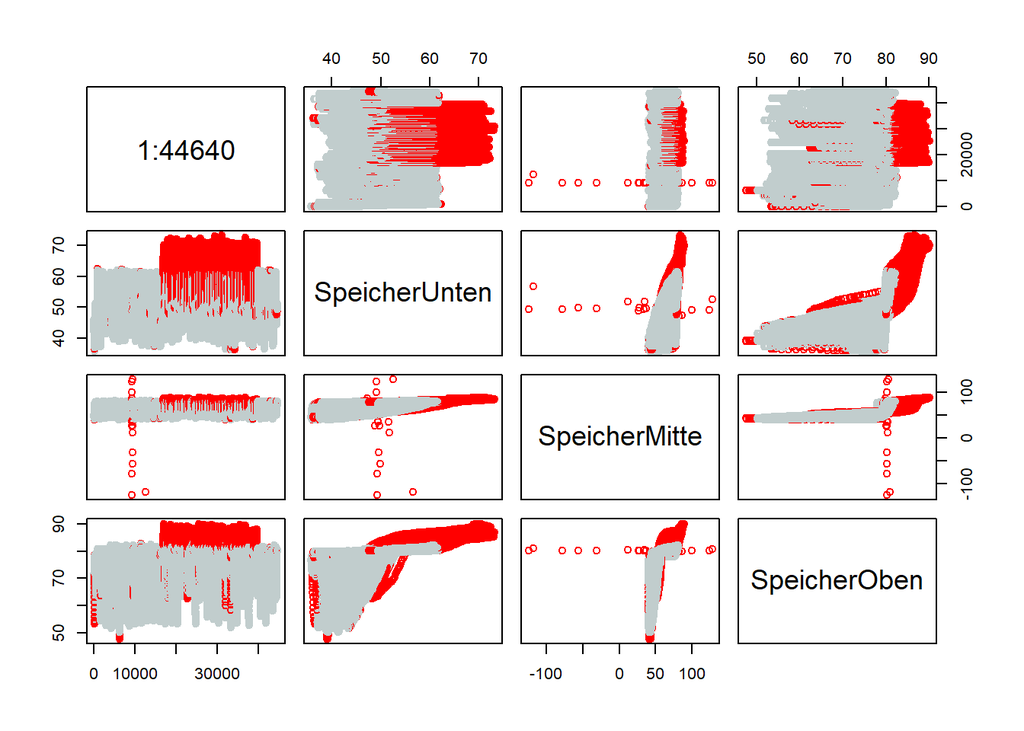

```r
pairs(cbind(1:44640, dat[,4:6]), col = ifelse(pred_total, "azure3", "red"))
```

### 1.2 Unsupervized Anomaly Detection: Isolation Forest

Get an idea how the isolation Forest (iForest) works on [wikipedia](https://en.wikipedia.org/wiki/Isolation_forest) or [orginal doc](https://cs.nju.edu.cn/zhouzh/zhouzh.files/publication/tkdd11.pdf). In contrast to the one-cass svm the iForest creates an *anomaly score* for each data instance.

```r
# load package containing isolation forests
library(isotree)
```

```r
# train a isoForest with 10 trees
isoForest <- isolation.forest(train[,features], ntrees = 100)
```

Use the iForest to compute an anomaly score for the training data instances.

```r
anomalyScore <- predict(isoForest, train[,features])
threshold <- 0.62
```

Plot the anomaly score for the training set.

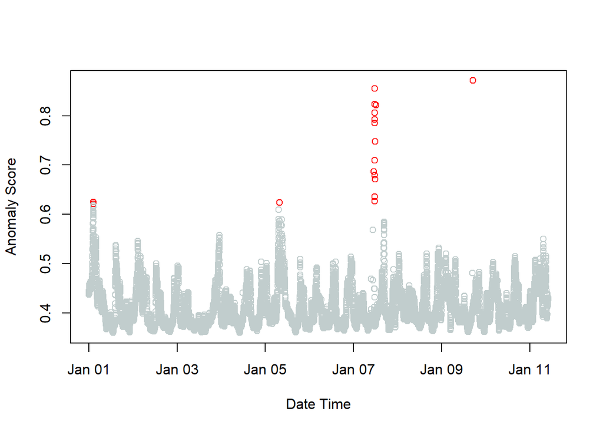

```r
plot(train$DateTime, anomalyScore,
      xlab = "Date Time", ylab = "Anomaly Score",
     col = ifelse(anomalyScore > threshold, "red", "azure3"))
```

Does the training set contain anomalies? Can you explain them?

**Your Answer:** **Yes, the training data has some anomalies which are shown on red color.** **Most of these anomalies correspond to the values shown as outliers** **in the SpeicherMitte Data**

Decide what a reasonable anomaly score threshold could be for the training data. Count the anomalies in the training set based using that threshold.

**The threshold selected was 0.62. This value was found after testing** **different values and finding the best match for the outliers (red color dots)** **shown on the plot**

```r
isanomaly = anomalyScore > threshold
table(isanomaly)["TRUE"]
```

```
## TRUE
##   17
```

Visualize the the training data set while using the anomaly score or labels to color the points.

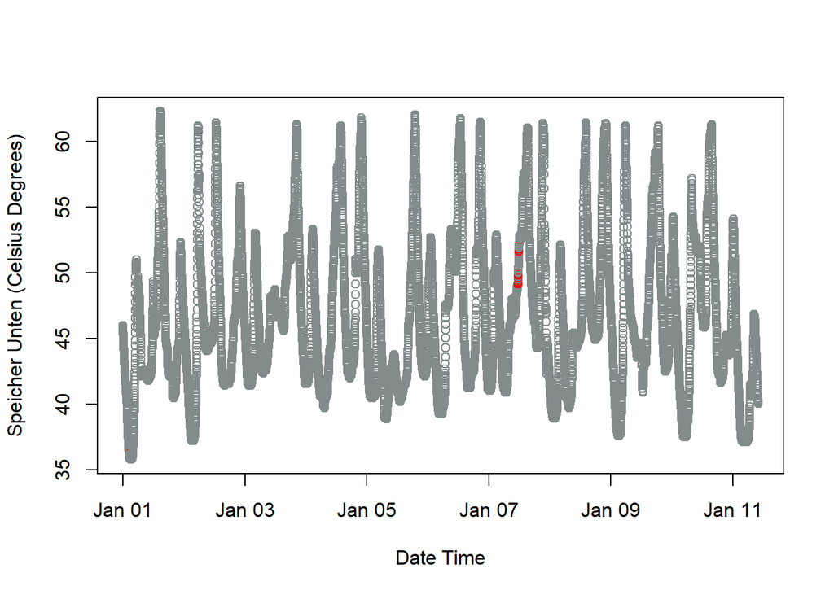

```r
plot(train$DateTime, train$SpeicherUnten,
     xlab = "Date Time", ylab = "Speicher Unten (Celsius Degrees)",
     col = ifelse(anomalyScore > threshold, "red", "azure4"))
```

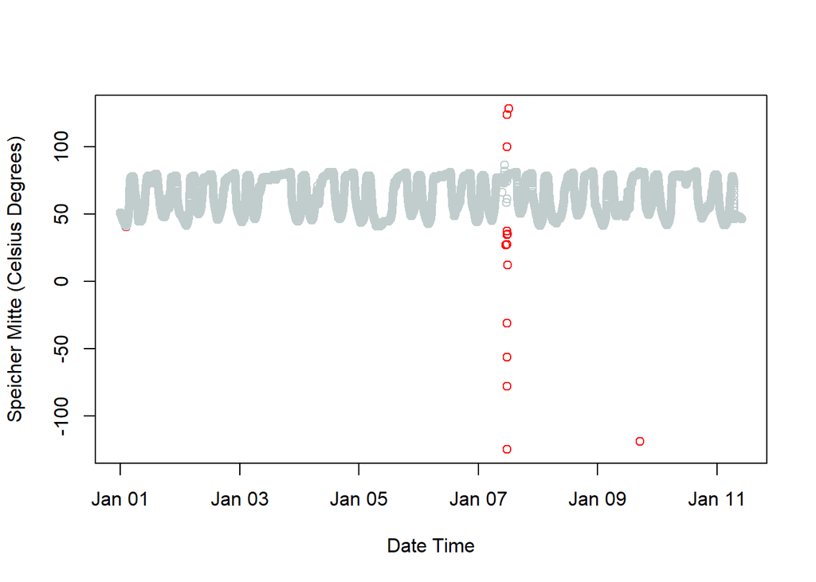

```r
plot(train$DateTime, train$SpeicherMitte,
     xlab = "Date Time", ylab = "Speicher Mitte (Celsius Degrees)",
     col = ifelse(anomalyScore > threshold, "red", "azure3"))
```

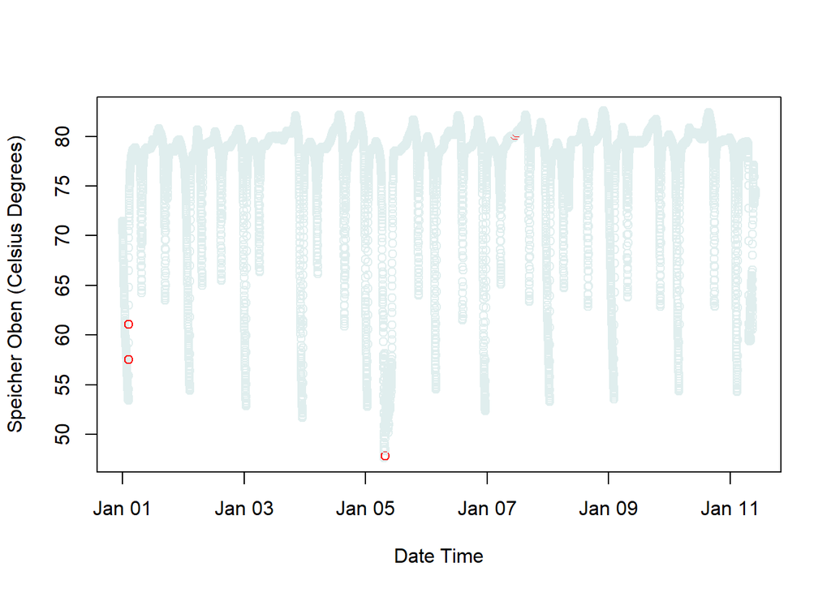

```r
plot(train$DateTime, train$SpeicherOben,
     xlab = "Date Time", ylab = "Speicher Oben (Celsius Degrees)",
     col = ifelse(anomalyScore > threshold, "red", "azure2"))
```

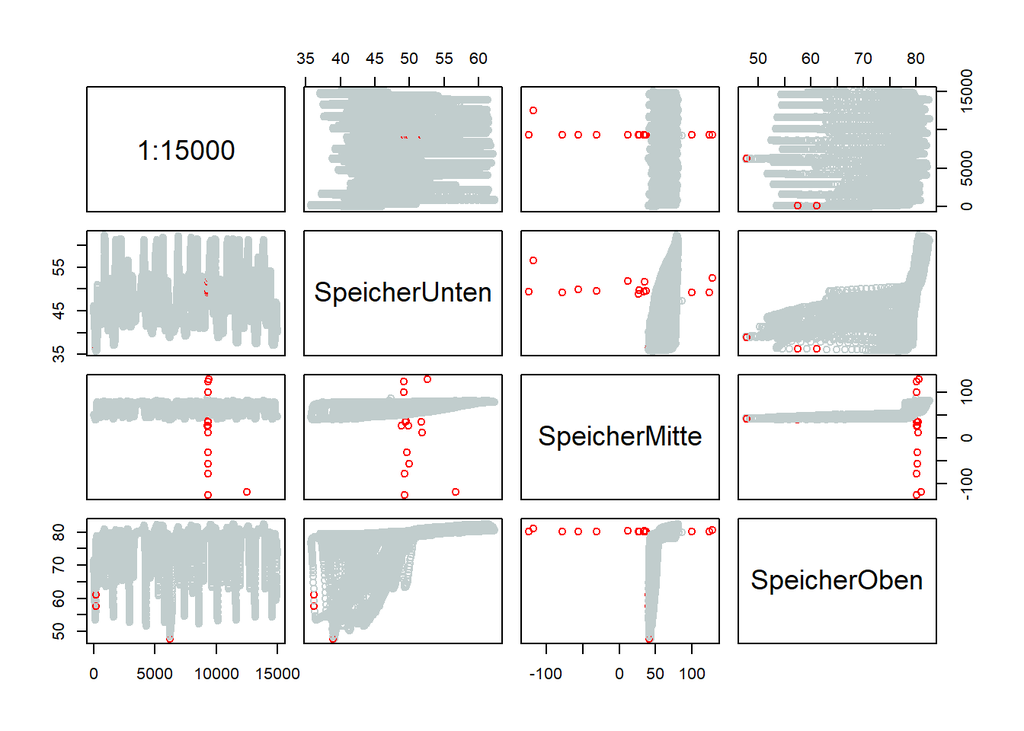

```r
pairs(cbind(1:15000, train[,4:6]),
      col = ifelse(anomalyScore> threshold, "red", "azure3"))
```

Apply the isolation forest model to the complete data set.

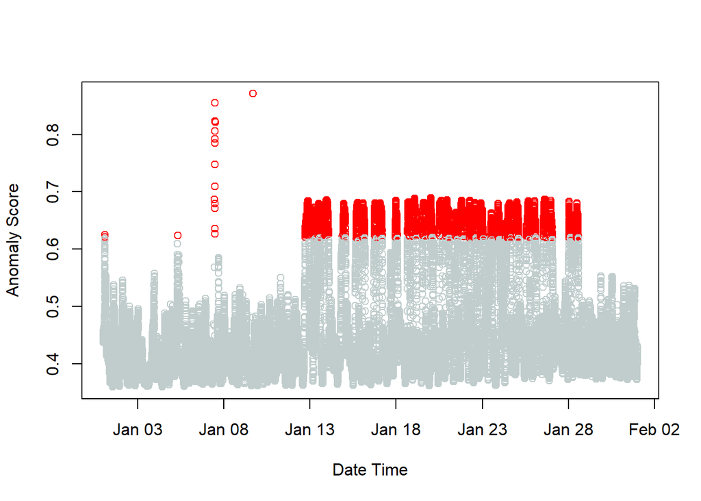

```r
anomalyScore <- predict(isoForest, dat[,features])
plot(dat$DateTime, anomalyScore,
      xlab = "Date Time", ylab = "Anomaly Score",
     col = ifelse(anomalyScore> threshold, "red", "azure3"))
```

Count the total number of anomalies (using the previously defined treshold) and again visualize the dataset and anomalies.

```r
isanomaly = anomalyScore > threshold
table(isanomaly)["TRUE"]
```

```
## TRUE
## 6088
```

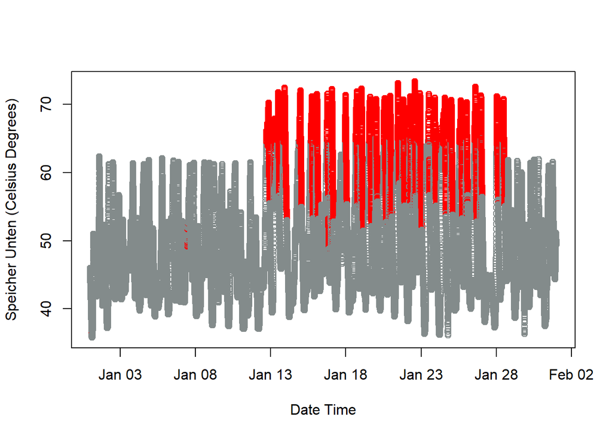

```r
plot(dat$DateTime, dat$SpeicherUnten,
     xlab = "Date Time", ylab = "Speicher Unten (Celsius Degrees)",
     col = ifelse(anomalyScore > threshold, "red", "azure4"))
```

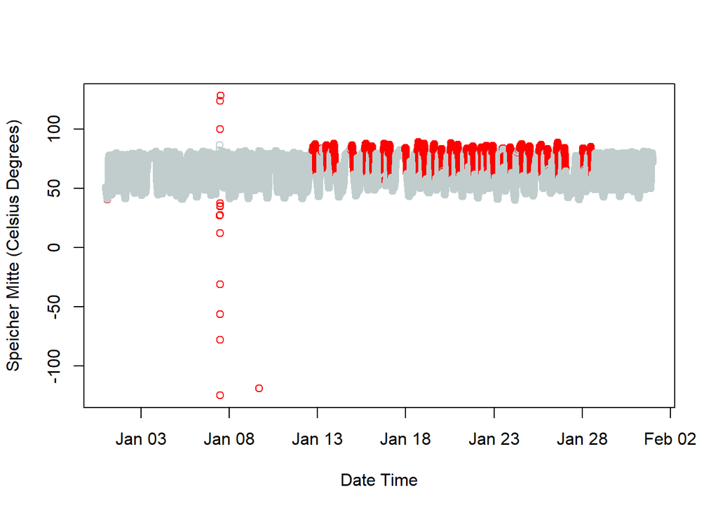

```r
plot(dat$DateTime, dat$SpeicherMitte,
     xlab = "Date Time", ylab = "Speicher Mitte (Celsius Degrees)",
     col = ifelse(anomalyScore > threshold, "red", "azure3"))
```

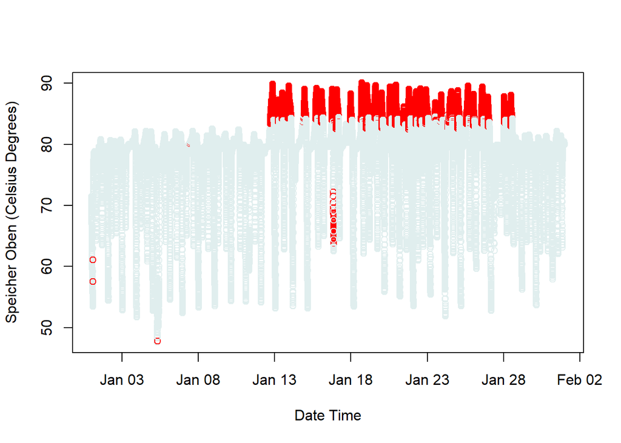

```r
plot(dat$DateTime, dat$SpeicherOben,
     xlab = "Date Time", ylab = "Speicher Oben (Celsius Degrees)",
     col = ifelse(anomalyScore > threshold, "red", "azure2"))
```

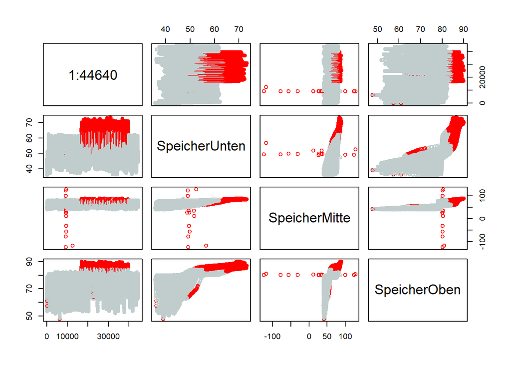

```r
pairs(cbind(1:44640, dat[,4:6]),
      col = ifelse(anomalyScore> threshold, "red", "azure3"))
```

Briefly discuss and interpret the results and the choice of the threshhold.

**Your answer:**

**The threshold was selected so that the number of anomalies observed in the** **plots are not very high and not very low. If the number of anomalies is very** **high, datavalues that are in the normal range can be taken as anomalies.** **If the number of anomalies is very low, then incorrect values could be taken.** **For the reasons explained before, plotting the variables with the threshold** **is very immportant so that the correct threshold can be selected.**

### 1.3 Your model

Repeat the previous procedure for an anomaly detection method of your choice. Document your results and briefly discuss and compare them to the two previous approaches.

The method chosen is Multivariate Outlier Detection and Replacement by Random Forest Predictions. However, the replacement method was not carried out.

```r
library(outForest)
out <- outForest(train[,features], threshold = 5, replace = "no", allow_predictions = TRUE, min.node.size=10 )
```

```
##
## Outlier identification by random forests
##
##   Variables to check:        SpeicherUnten, SpeicherMitte, SpeicherOben
##   Variables used to check:   SpeicherUnten, SpeicherMitte, SpeicherOben
##
##   Checking: SpeicherUnten  SpeicherMitte  SpeicherOben
```

```r
table(out$is_outlier)
```

```
##
## FALSE  TRUE
## 44898   102
```

```r
SU_outlier <- out$is_outlier[,1]
table(SU_outlier)["TRUE"]
```

```
## TRUE
##    1
```

```r
SM_outlier <- out$is_outlier[,2]
table(SM_outlier)["TRUE"]
```

```
## TRUE
##   12
```

```r
SO_outlier <- out$is_outlier[,3]
table(SO_outlier)["TRUE"]
```

```
## TRUE
##   89
```

**Your answer: Multivariate Outlier Detection and Replacement by** **Random Forest Predictions**

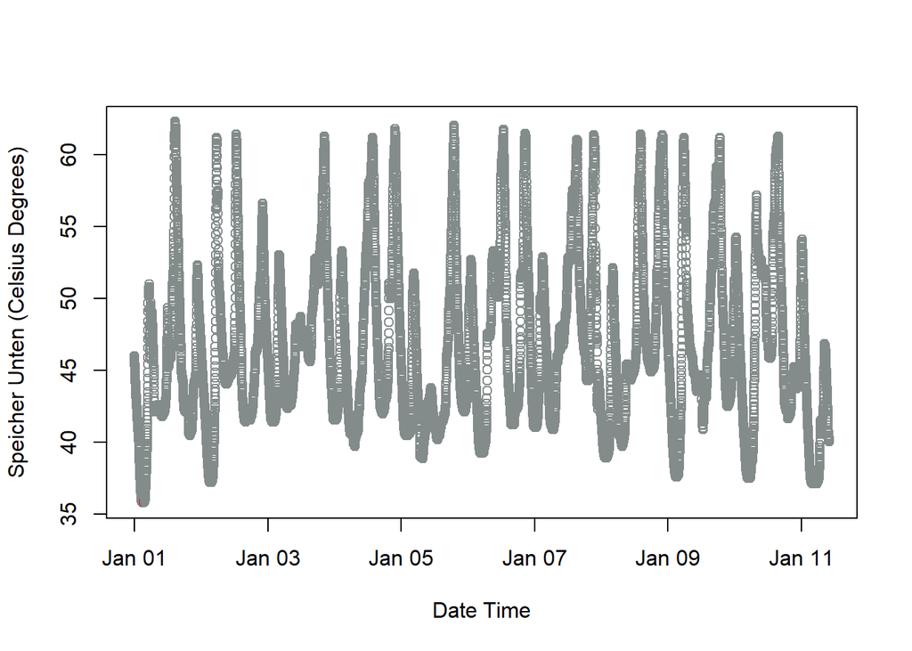

```r
plot(dat$DateTime[trainIndex], dat$SpeicherUnten[trainIndex],
     xlab = "Date Time", ylab = "Speicher Unten (Celsius Degrees)",
     col = ifelse(SU_outlier, "red", "azure4") )
```

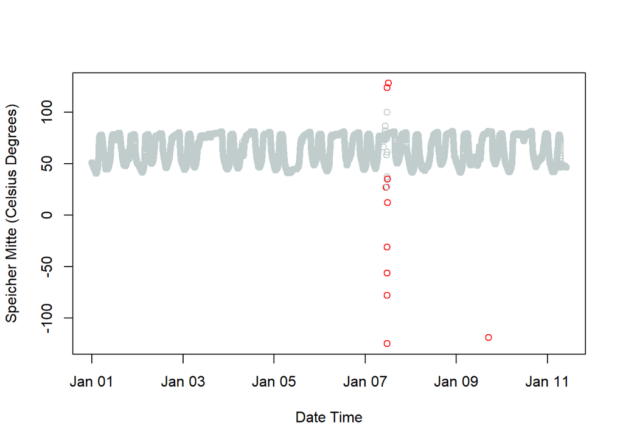

```r
plot(dat$DateTime[trainIndex], dat$SpeicherMitte[trainIndex],
     xlab = "Date Time", ylab = "Speicher Mitte (Celsius Degrees)",
     col = ifelse(SM_outlier, "red", "azure3") )
```

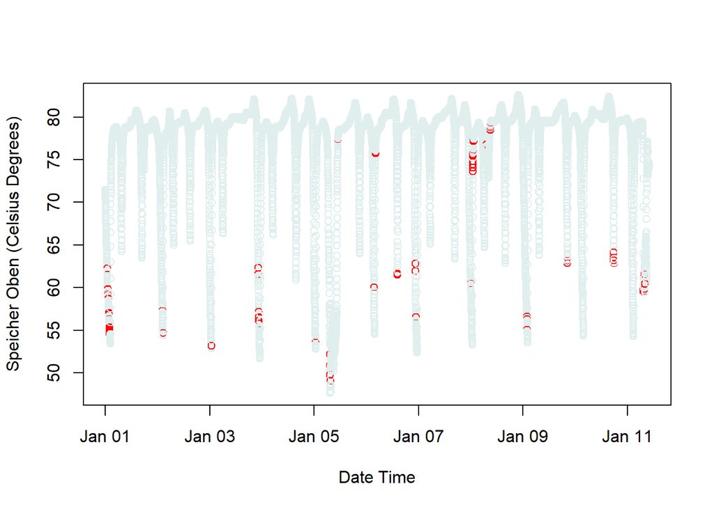

```r
plot(dat$DateTime[trainIndex], dat$SpeicherOben[trainIndex],
     xlab = "Date Time", ylab = "Speicher Oben (Celsius Degrees)",
     col = ifelse(SO_outlier, "red", "azure2") )
```

**For this dataset, this method is not appropriate. Let’s see why:** **The method classifies properly the anomalies in the SpeicherMitte variable** **However, it does not detect them well for the variable SpeicherOben**

**Each numeric variable to be checked for outliers is regressed onto all other** **variables using a random forest. If the scaled absolute difference between** **observed value and out-of-bag prediction is larger than some predefined** **threshold (default is 3, for this case was 5 ),** **then a value is considered an outlier**

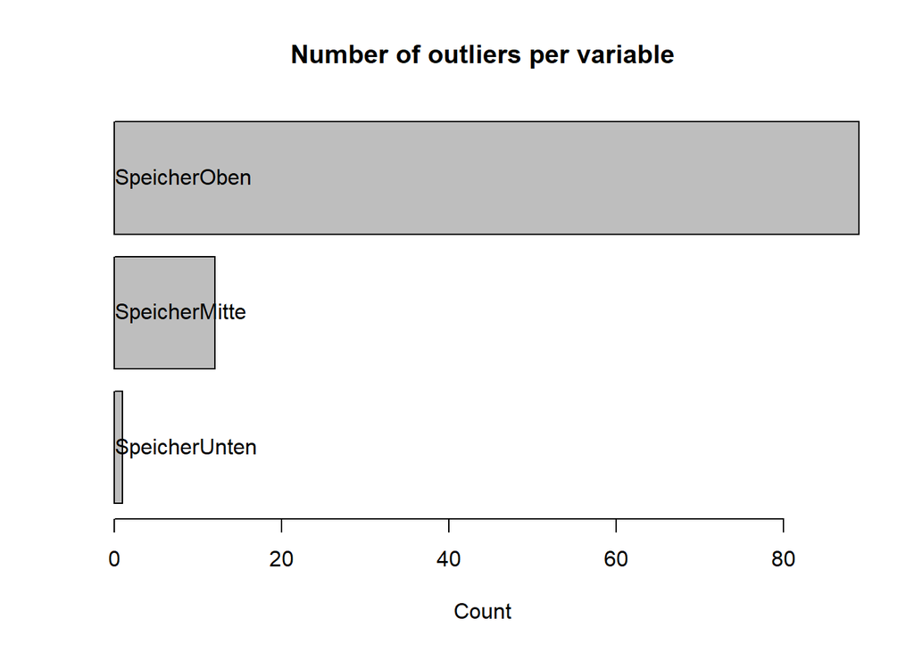

```r
plot(out)
```

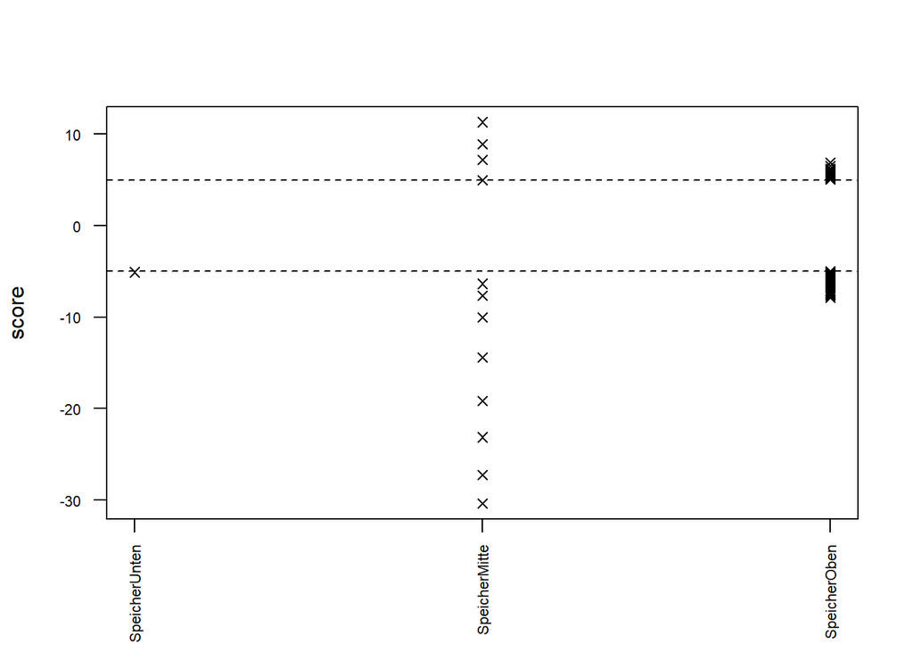

```r
plot(out, what = "scores")
```

Prediction

```r
pred_dat <- predict(out, dat[,features], replace = "no",
                    threshold = out$threshold)
pred_dat_out <- outForest(pred_dat$Data, threshold = 5,
                          replace = "no", allow_predictions = TRUE,
                          min.node.size=10, )
```

```
##
## Outlier identification by random forests
##
##   Variables to check:        SpeicherUnten, SpeicherMitte, SpeicherOben
##   Variables used to check:   SpeicherUnten, SpeicherMitte, SpeicherOben
##
##   Checking: SpeicherUnten  SpeicherMitte  SpeicherOben
```

```r
table(pred_dat_out$is_outlier)
```

```
##
##  FALSE   TRUE
## 133660    260
```

```r
SU_outlier_pred <- pred_dat_out$is_outlier[,1]
table(SU_outlier_pred)["TRUE"]
```

```
## TRUE
##   54
```

```r
SM_outlier_pred <- pred_dat_out$is_outlier[,2]
table(SM_outlier_pred)["TRUE"]
```

```
## TRUE
##   15
```

```r
SO_outlier_pred <- pred_dat_out$is_outlier[,3]
table(SO_outlier_pred)["TRUE"]
```

```
## TRUE
##  191
```

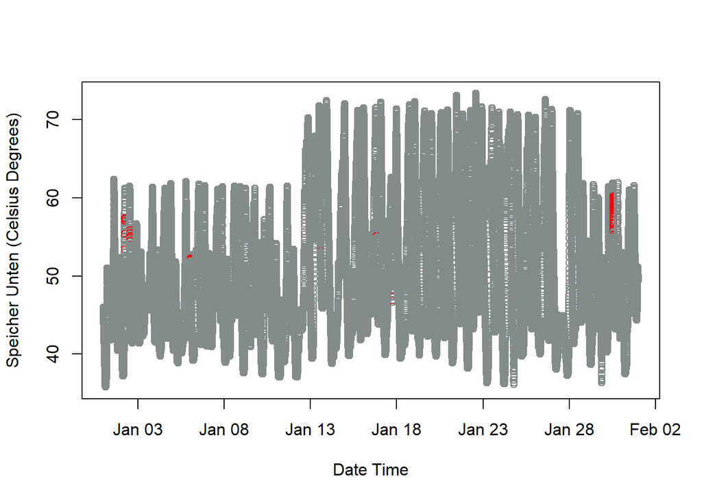

```r
plot(dat$DateTime, dat$SpeicherUnten,
     xlab = "Date Time", ylab = "Speicher Unten (Celsius Degrees)",
     col = ifelse(SU_outlier_pred, "red", "azure4") )
```

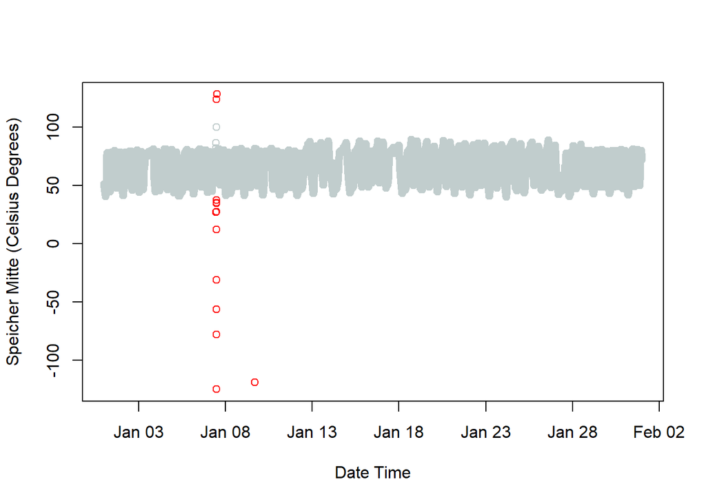

```r
plot(dat$DateTime, dat$SpeicherMitte,
     xlab = "Date Time", ylab = "Speicher Mitte (Celsius Degrees)",
     col = ifelse(SM_outlier_pred, "red", "azure3") )
```

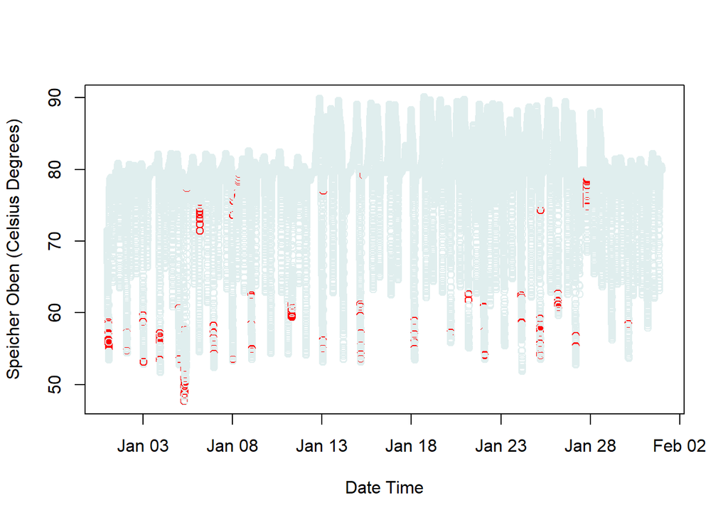

```r
plot(dat$DateTime, dat$SpeicherOben,
     xlab = "Date Time", ylab = "Speicher Oben (Celsius Degrees)",
     col = ifelse(SO_outlier_pred, "red", "azure2") )
```

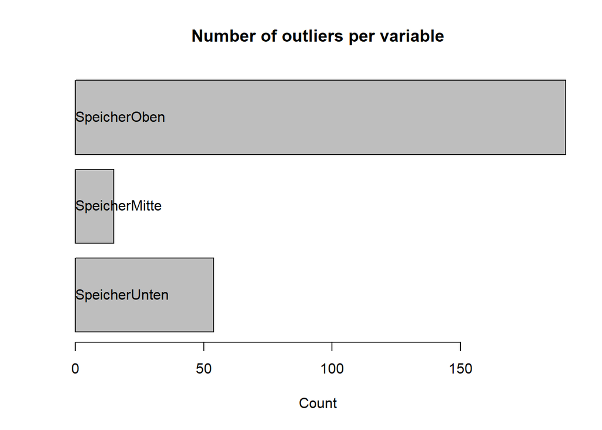

```r
plot(pred_dat_out)
```

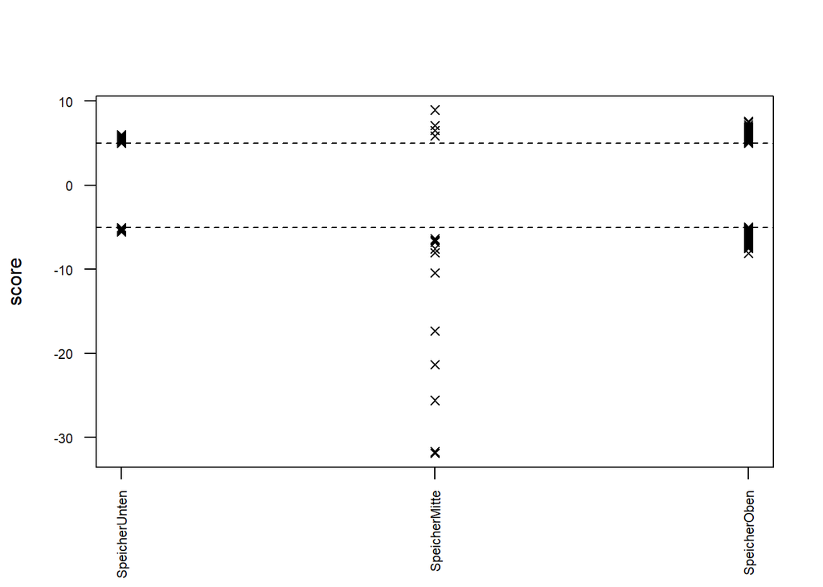

```r
plot(pred_dat_out, what = "scores")
```